# CVDRM PSED Report

### Premature Deaths from circulatory disease

**Age**

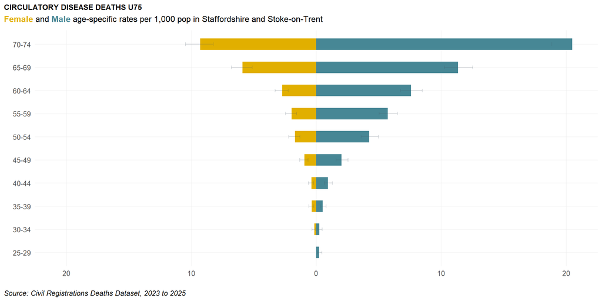

**Sex or Stated Gender**

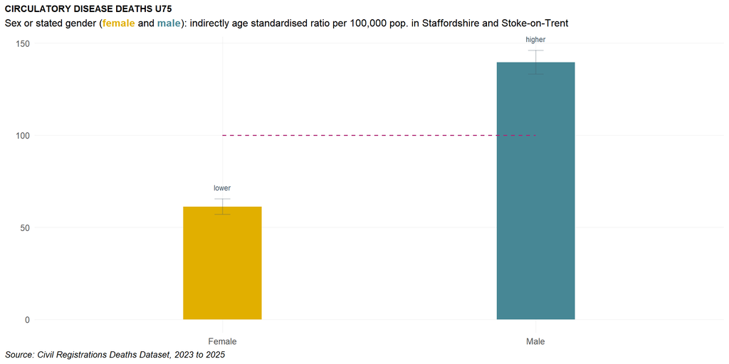

**Ethnicity**

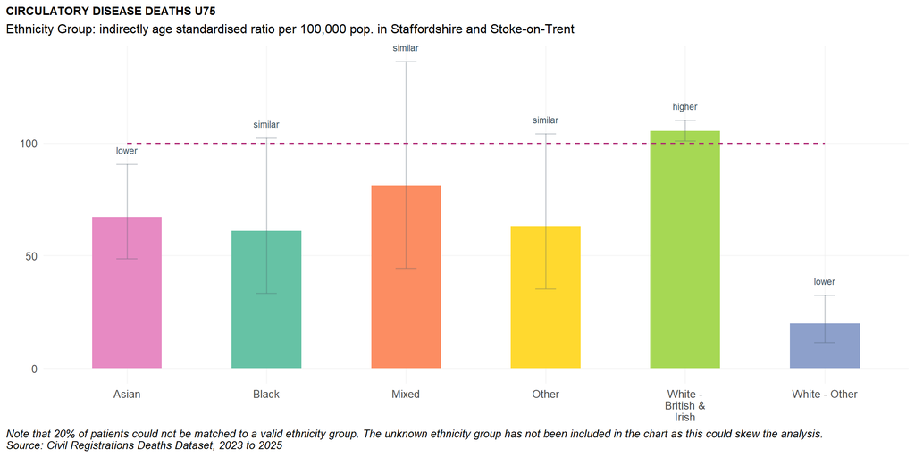

**Deprivation**

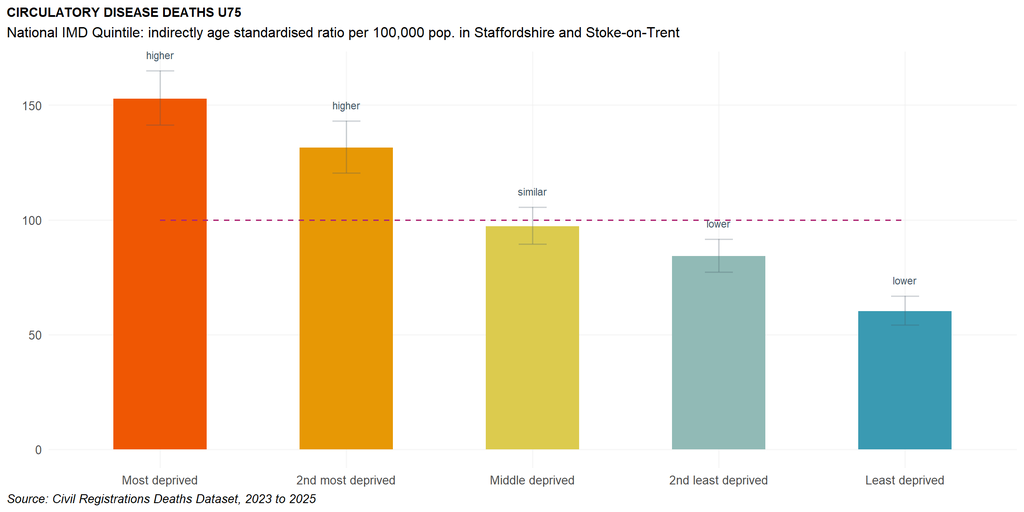

**Urban-Rural**

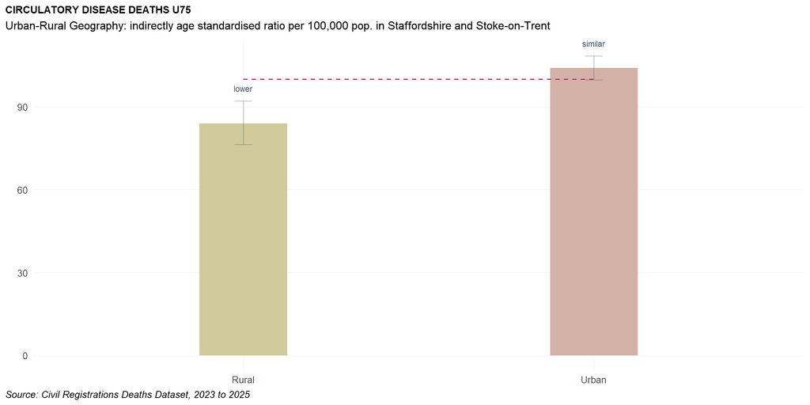

- Rates are highest in the 70-74 age group, whilst the median age is approx. 66 years.
- Males had a significantly higher rate, whilst females had a significantly lower rate.
- Patients of White - British & Irish ethnicity had a significantly higher rate, whilst patients of Asian ethnicity or patients of White - Other ethnicity had a significantly lower rate.
- Patients from the two most deprived groups had a significantly higher rate whilst patients from the two least deprived groups had a significantly lower rate.
- Patients from rural areas had a significantly lower rate.

### Premature Deaths from diabetes (any mention)

**Age**

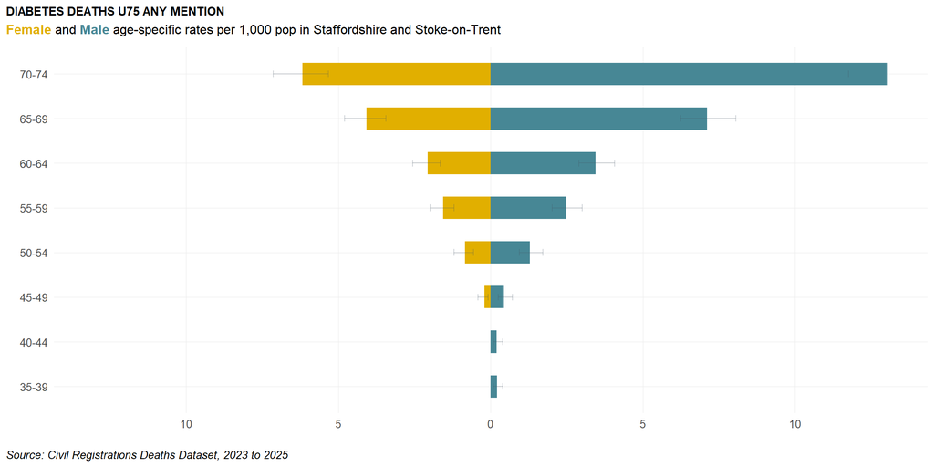

**Sex or Stated Gender**

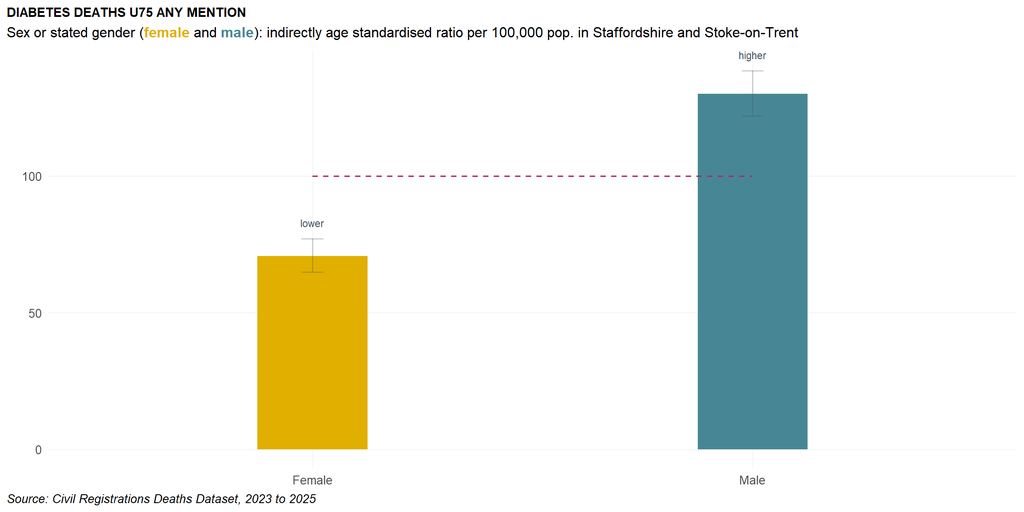

**Ethnicity**

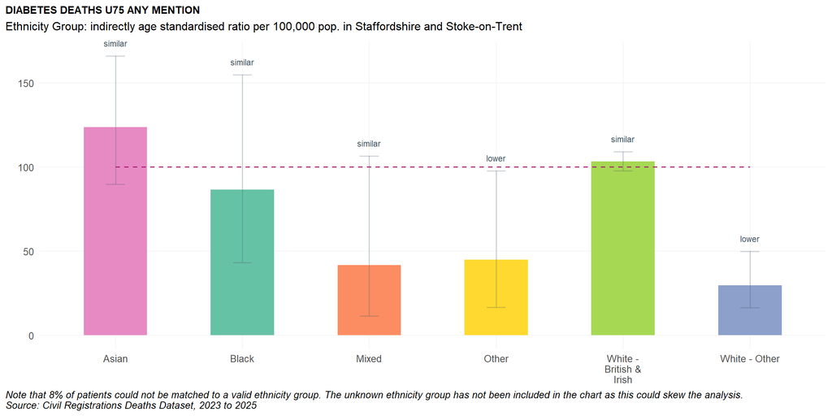

**Deprivation**

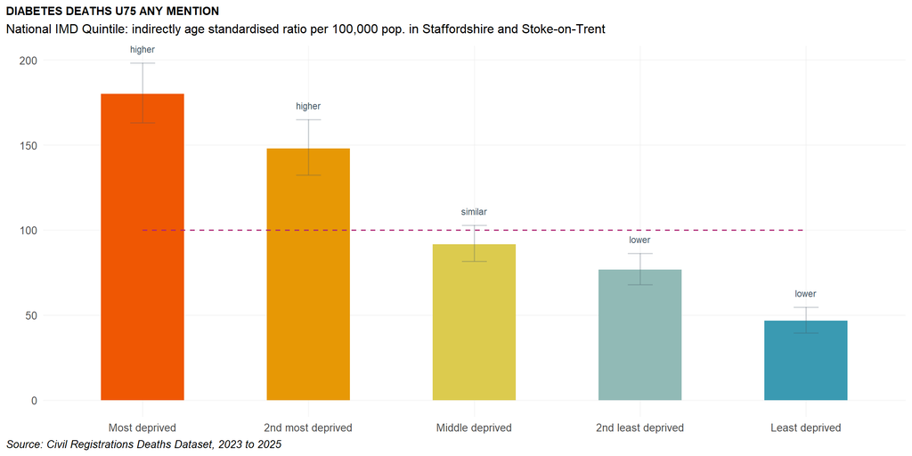

**Urban-Rural**

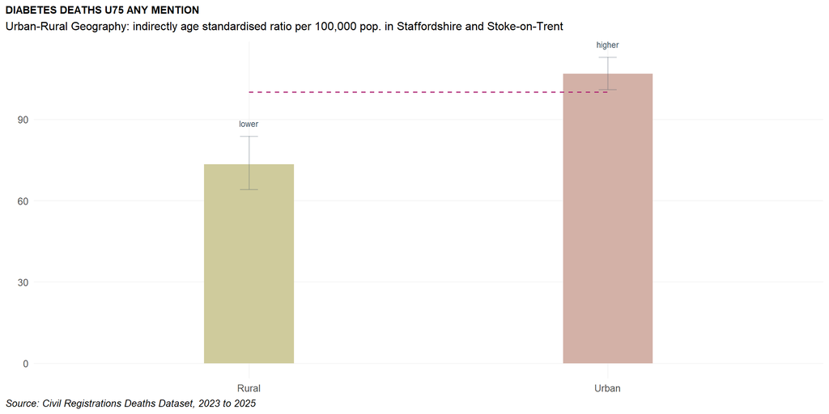

- Rates are highest in the 70-74 age group, whilst the median age is approx. 68 years.
- Males had a significantly higher rate, whilst females had a significantly lower rate.
- Patients of Other ethnicity or patients of White - Other ethnicity had a significantly lower rate.
- Patients from the two most deprived groups had a significantly higher rate whilst patients from the two least deprived groups had a significantly lower rate.
- Patients from urban areas had a significantly higher rate, whilst patients from rural areas had a significantly lower rate.